# Les Présidents du conseil de la IIIe République, une exploration numérique (1871-1940)

## I - Constitution de la liste des Présidents du conseil

Pour ce faire, on utilise [cette page Wikipedia](https://fr.wikipedia.org/wiki/Liste_des_chefs_du_gouvernement_fran%C3%A7ais#Chronologie), on repère dans le code source le tableau qui correspond à la IIIe République et on "parse" les données qui nous intéressent.

```python
import pandas as pd
import requests
from bs4 import BeautifulSoup
import dateparser
import seaborn as sns
import numpy as np
from tqdm import tqdm

wikiurl = "https://fr.wikipedia.org/wiki/Liste_des_chefs_du_gouvernement_fran%C3%A7ais#Chronologie"
response=requests.get(wikiurl)
soup = BeautifulSoup(response.text, 'html.parser')
tables=soup.find_all('table',{'class':"wikitable"})

df=pd.read_html(str(tables))

noms = df[8].iloc[:,2].values # On  tableau qui nous intéresse est le 8e
noms = [nom.split("(")[0] for nom in noms]
noms_simple = [nom.strip().split(" ")[-1] for nom in noms] #On ne garde le dernier nom de famille, par simplicité
results = pd.DataFrame(noms_simple)
results.columns = ["Noms"]
dates = df[8].iloc[:,4].values #Idem pour les dates de mandat
dates_nomination = [date.split("–")[0].strip() for date in dates]
results["date_nomination"] = pd.to_datetime([dateparser.parse(date).date() for date in dates_nomination])
dates_demission = [date.split("–")[1].strip() for date in dates]
results["date_démission"] = pd.to_datetime([dateparser.parse(date).date() for date in dates_demission])
#On calcule la longévité de chaque gouvernement
results["Longévité"] = results.date_démission - results.date_nomination
results.Longévité = [results.Longévité[i].days for i in results.index]
results["Mort_né"] = results.Longévité < np.timedelta64(31,"D") #On note si les gouvernements ont duré moins d'un mois
#On crée aussi des colonnes pour noter si le PdC a été reconduit après sa démission ou effectue un 2nd mandat
results["Reconduit"] = [noms_simple[i+1]==noms_simple[i] for i in range(len(noms_simple)-1)] + [True]
results["Reconduit"][[51,65]] = True #On considère comme reconduits Poincaré et Millerand, qui ont enchaîné avec l'élysée
results["Second_mandat"] = [False] + [noms_simple[i-1]==noms_simple[i] for i in range(len(noms_simple)-1)]
```

**Tadam !**

```python
results
```

|  | Noms | date_nomination | date_démission | Longévité | Mort_né | Reconduit | Second_mandat |
| --- | --- | --- | --- | --- | --- | --- | --- |
| 0 | Dufaure | 1871-02-17 | 1873-05-18 | 821 days | False | True | False |
| 1 | Dufaure | 1873-05-18 | 1873-05-24 | 6 days | True | False | False |
| 2 | Broglie | 1873-05-25 | 1873-11-24 | 183 days | False | True | True |
| 3 | Broglie | 1873-11-24 | 1874-05-16 | 173 days | False | False | False |
| 4 | Cissey | 1874-05-22 | 1875-02-25 | 279 days | False | False | True |
| ... | ... | ... | ... | ... | ... | ... | ... |
| 104 | Daladier | 1938-04-12 | 1939-05-13 | 396 days | False | True | False |
| 105 | Daladier | 1939-05-13 | 1939-09-13 | 123 days | False | True | False |
| 106 | Daladier | 1939-09-13 | 1940-03-20 | 189 days | False | False | True |
| 107 | Reynaud | 1940-03-22 | 1940-06-16 | 86 days | False | False | True |
| 108 | Pétain | 1940-06-16 | 1940-07-10 | 24 days | True | True | False |

109 rows × 7 columns

## II - Calcul des fréquences d'occurrences dans la presse de Gallica

Maintenant qu'on a leur noms, on va faire une analyse lexicométrique, i.e. s'intéresser à leur présence dans la presse française de l'époque. Bénis soit-ils, [*Gallica*](https://gallica.bnf.fr/) a numérisé une bonne partie de la presse de cette époque. Le corpus est conséquent : jusqu'à 50 000 numéros par an sur la période. Charger et analyser tous ces documents prendrait un temps fou et beaucoup trop de place pour mon petit ordinateur. Heureusement, deux petits bricolos l'ont déjà fait une fois pour toutes pour réaliser [Gallicagram](https://shiny.ens-paris-saclay.fr/app/gallicagram). Ils ont téléchargé les 3 millions de numéros de presse numérisés par Gallica sur un gros ordinateur et compté sur chaque mois combien de fois chaque mot avait été employé. La base de données constituée par ces comptages est stockée sur un serveur à l'ENS Paris-Saclay. Elle est trop volumineuse pour la télécharger, mais on peut l'interroger à distance avec le package [`pyllicagram`](https://github.com/regicid/pyllicagram).

Insistons pour que cela soit parfaitement clair : ce qui est calculé ici est la **fréquence du syntagme**. On compte le nombre de fois que le mot "Freycinet" est employé chaque mois, et on le divise par le nombre total de mots dont dispose le corpus sur la période.

On va donc interroger la base de données sur la fréquence d'occurrences de chaque Président du Conseil autour de leur passage au pouvoir et visualiser les séries pour commencer. Je vous invite à scroller parmi les 109 graphes ci-dessous. La première barre verticale marque la nomination, la seconde la démission.

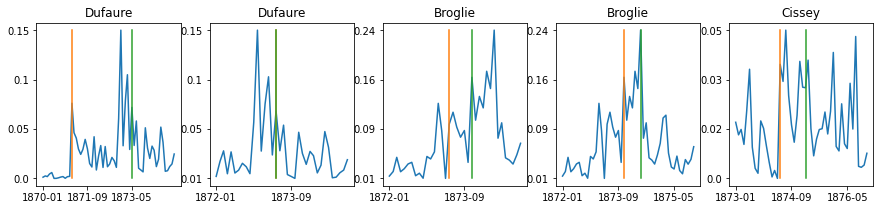

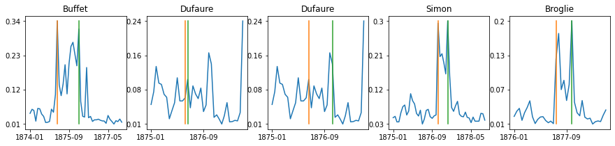

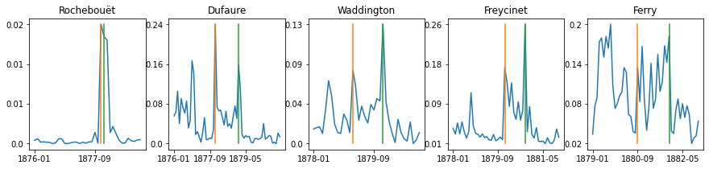

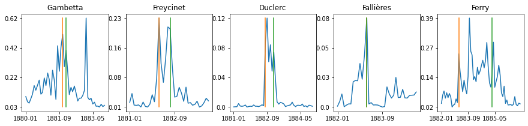

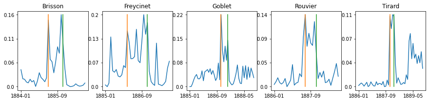

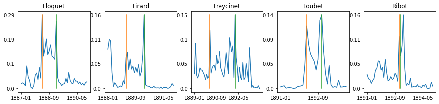

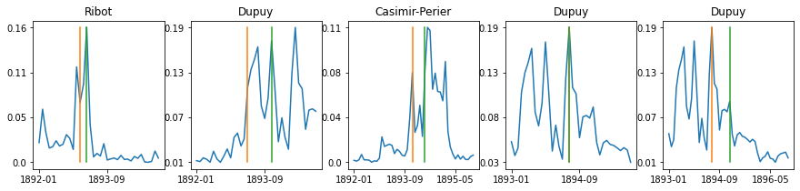

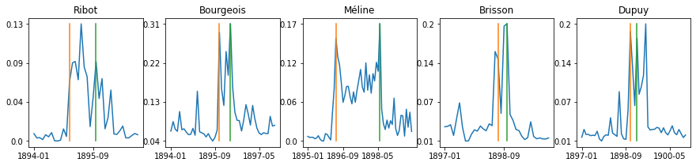

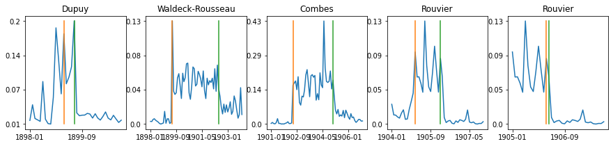

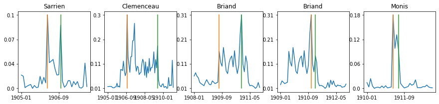

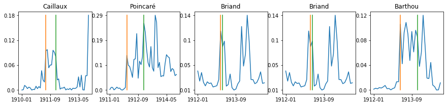

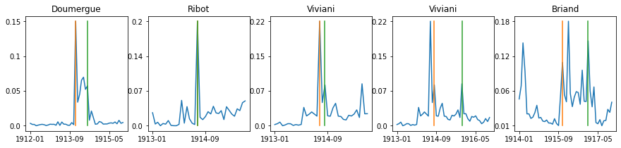

[10 more figures not shown]

```python
from pyllicagram import pyllicagram
import urllib
from calendar import monthrange
import matplotlib.pyplot as plt
from dateutil.relativedelta import relativedelta
nomination = []
demission = []
mandat = []
avant_nomination = []
apres_demission = []

def multiplot_from_generator(g, num_columns, figsize_for_one_row=None):
    # call 'next(g)' to get past the first 'yield'
    next(g)
    # default to 15-inch rows, with square subplots
    if figsize_for_one_row is None:
        figsize_for_one_row = (15, 15/num_columns)
    try:
        while True:
            # call plt.figure once per row
            plt.figure(figsize=figsize_for_one_row)
            for col in range(num_columns):
                ax = plt.subplot(1, num_columns, col+1)
                next(g)
    except StopIteration:
        pass


def plotter():
    for i in range(len(noms)):
        yield
        a = pyllicagram.pyllicagram(urllib.parse.quote_plus(noms_simple[i].lower()).replace("-"," ").replace("+"," "),
                                    debut=results.date_nomination[i].year-1,
                                    fin=results.date_démission[i].year+1,corpus="presse",resolution="mois")

        num_days = monthrange(results.date_nomination[i].year,results.date_nomination[i].month)[1]
        z = np.where((a.annee == results.date_nomination[i].year) * (a.mois == results.date_nomination[i].month + (num_days - results.date_nomination[i].day < 3)))[0][0]
        zz = np.where((a.annee == results.date_démission[i].year) * (a.mois == results.date_démission[i].month))[0][0]
        nomination.append(a.ratio[z])
        avant_nomination.append(a.ratio[z-6:z].mean())
        demission.append(a.ratio[zz])
        apres_demission.append(a.ratio[zz+1:zz+7].mean())
        mandat.append(a.ratio[z+1:zz-1].mean())
        times = np.arange(results.date_nomination[i]-relativedelta(months = results.date_nomination[i].month+11),results.date_démission[i]+relativedelta(months = 25 -results.date_démission[i].month),np.timedelta64(1, 'M'),dtype='datetime64[M]')
        plt.plot(times,a.ratio)
        plt.plot([times[z],times[z]],[a.ratio.min(),a.ratio.max()])
        plt.plot([times[zz],times[zz]],[a.ratio.min(),a.ratio.max()])
        plt.xticks(times[::20],times[::20])
        plt.yticks(np.linspace(a.ratio.min(),a.ratio.max(),4),np.linspace(10**3*a.ratio.min(),10**3*a.ratio.max(),4).round(2))
        plt.title(noms_simple[i])

multiplot_from_generator(plotter(),5)
```

On remarque un motif clair qui s'installe à partir de Jules Simon. Les mentions des PdC connaissent des pics lors de la nomination et de la démission. Les mentions restent hautes au cours du mandat et dégringolent plus ou moins par la suite. C'est assez satisfaisant : si j'étais fainéant et ignorais tout de la chronologie des PdC, je pourrais plus ou moins la reconstituer avec mes données.

Pour notre projet, l'existence de telles régularités est une bonne nouvelle. On peut extraire plusieurs mesures qui décrivent en quelque sorte le destin d'un gouvernement. On incorpore es mesures (calculées dans le code plus haut) à notre tableau :

- Le mois où il est nommé (`Nomination`)
- Le mois où il démissionne (`Démission`)
- Au long de son mandat (de sa nomination à sa démission) (`Mandat`)
- Les 6 mois précédant sa nomination (`Avant_nomination`)
- Les 6 mois suivant sa démission (`Après_démission`)

L'idée sous-jacente est d'utiliser ces mesures pour approcher la notoriété du personnage, le choc provoqué par sa nomination ou sa démission, le degré auquel il est déjà connu du grand public avant sa nomination et à quel point il est oublié par la suite.

```python
results["Nomination"] = nomination
results["Démission"] = demission
results["Mandat"] = mandat
results["Avant_nomination"] = avant_nomination
results["Après_démission"] = apres_demission
```

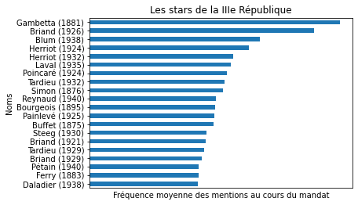

```python
top = results.sort_values(by="Mandat", ascending=False).head(20)
top["Noms"] = results["Noms"] + " (" + [str(results["date_nomination"][i].year) for i in range(len(results.index))] + ")"
top = top[["Noms","Mandat"]].iloc[::-1,]
top.plot.barh(x="Noms",legend=False)

plt.xticks([],[])
plt.xlabel("Fréquence moyenne des mentions au cours du mandat")
plt.title("Les stars de la IIIe République");
```

On peut aussi combiner nos mesures pour regarder, par exemple, quelles nominations ont dû paraître les plus suprenantes à leurs contemporains. Pour ce faire, on divise la présence dans la presse le mois de la nomination par la présence moyenne pendant les 6 mois précédents, pour mesurer en quelque sorte l'effet de surprise produit par la nomination.

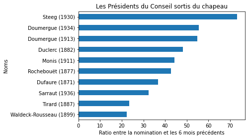

```python
results["Surprise"] = results["Nomination"]/results["Avant_nomination"]
top = results.sort_values(by="Surprise",ascending=False).head(10)
top = top[["Noms","Surprise"]].iloc[::-1,]
top["Noms"] = results["Noms"] + " (" + [str(results["date_nomination"][i].year) for i in range(len(results.index))] + ")"
top.plot.barh(x="Noms",legend=False)

plt.xlabel("Ratio entre la nomination et les 6 mois précédents")
plt.title("Les Présidents du Conseil sortis du chapeau")
```

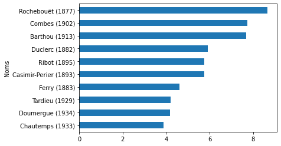

```python
results["Révélation"] = results["Après_démission"]/results["Avant_nomination"]
top = results.loc[~results.Reconduit].sort_values(by="Révélation",ascending=False).head(10)
top = top[["Noms","Révélation"]].iloc[::-1,]
top["Noms"] = results["Noms"] + " (" + [str(results["date_nomination"][i].year) for i in range(len(results.index))] + ")"
top.plot.barh(x="Noms",legend=False)
```